# Exploring Data

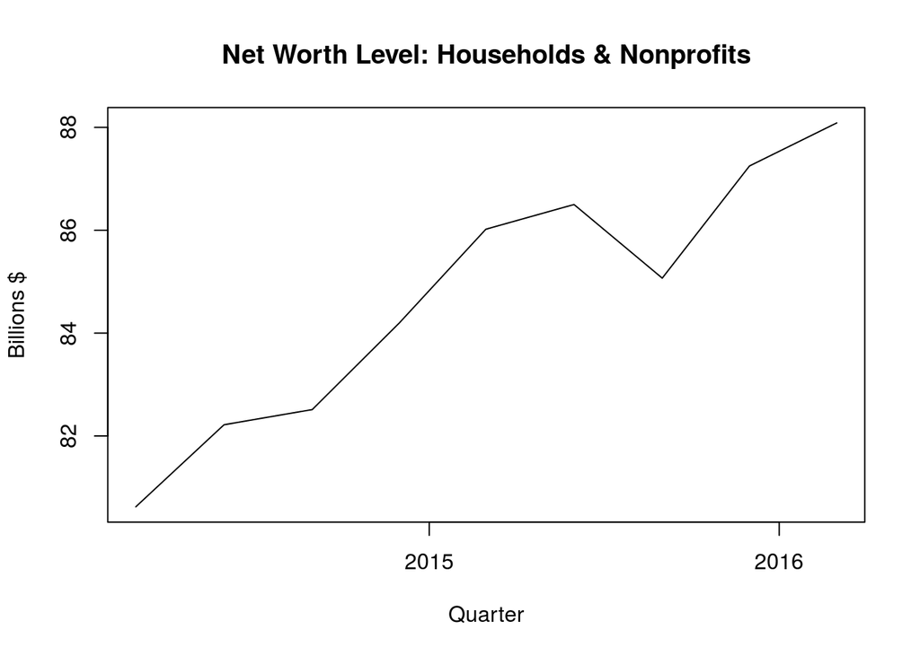

```r
with(subset(df, df$annual == FALSE),
     plot(date, household_net_worth, type = "l", main = "Net Worth Level: Households & Nonprofits", xlab = "Quarter", ylab = "Billions $")
)
```

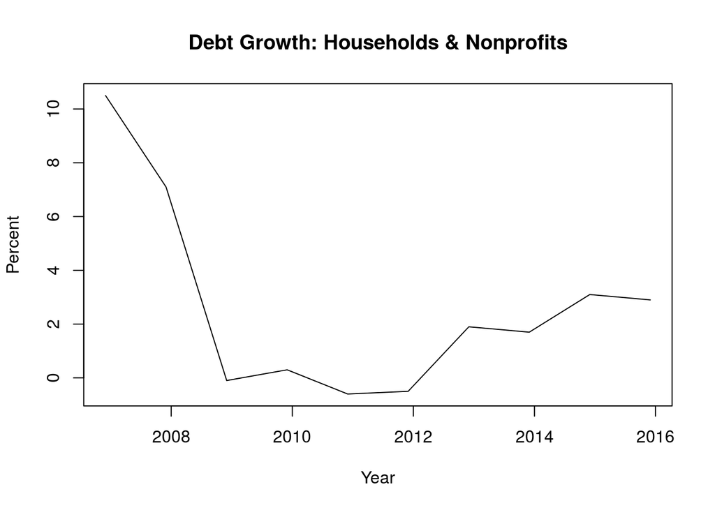

```r
with(subset(df, df$annual == TRUE),
     plot(date, household_debt_growth, type = "l", main = "Debt Growth: Households & Nonprofits", xlab = "Year", ylab = "Percent")
)
```

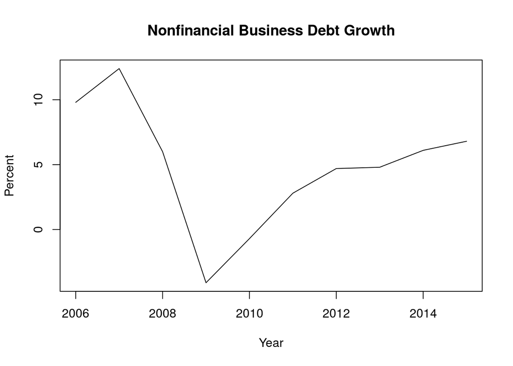

```r
with(subset(df, df$annual == TRUE),
     plot(year, business_debt_growth, type = "l", main = "Nonfinancial Business Debt Growth", xlab = "Year", ylab = "Percent")
)
```

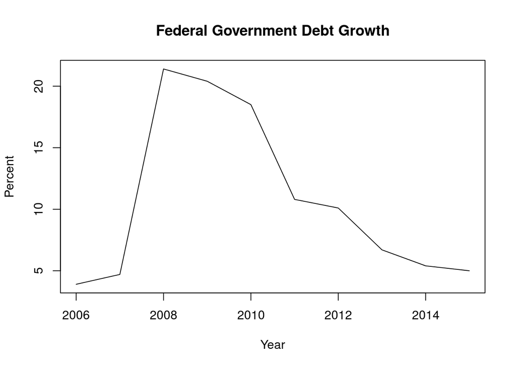

```r
with(subset(df, df$annual == TRUE),
     plot(year, federal_debt_growth, type = "l", main = "Federal Government Debt Growth", xlab = "Year", ylab = "Percent")
)
```

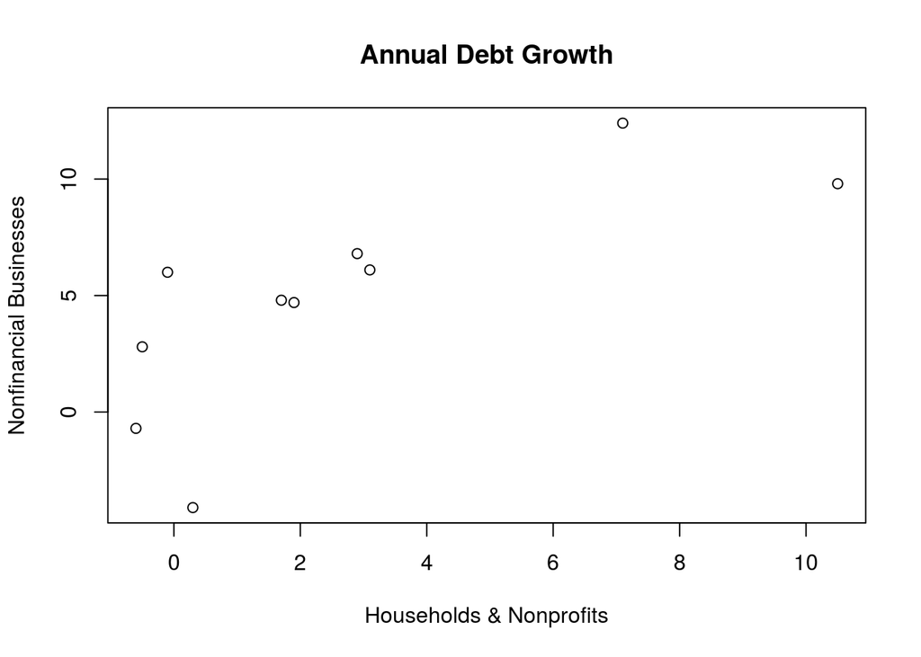

```r
# scatterplots
with(subset(df, df$annual == TRUE),
     plot(household_debt_growth, business_debt_growth, type = "p", main = "Annual Debt Growth", xlab = "Households & Nonprofits", ylab = "Nonfinancial Businesses")
)
```

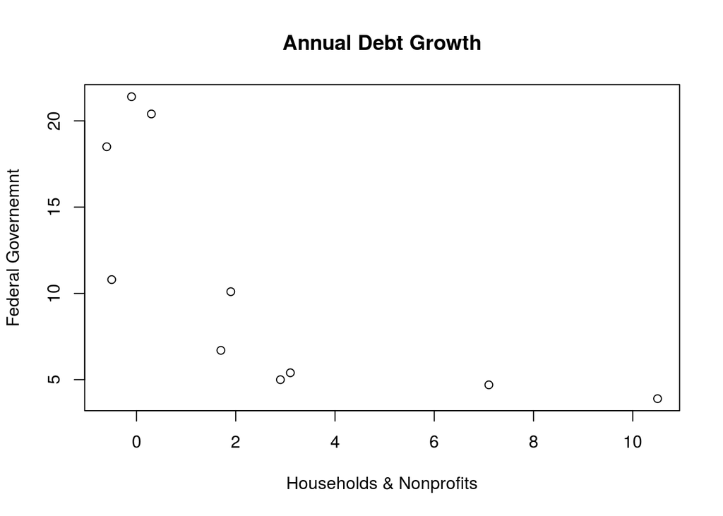

```r
with(subset(df, df$annual == TRUE),
     plot(household_debt_growth, federal_debt_growth, type = "p", main = "Annual Debt Growth", xlab = "Households & Nonprofits", ylab = "Federal Governemnt")
)
```

What can we say about the data?

### Time Series Example 2

The previous data set had very few observations. Other files in the zip archive provide more (table D1)

### Step 1 - Import

*In Class Exercise 5*

Read table D1 from the zip archive, and inspect the raw data.

```r
# Load Packages


# Data source
source_url <- "http://www.federalreserve.gov/releases/z1/z1-csv-20160617.zip"


# Download the zip file (if we need it)
if ( !file.exists("data/z1-csv-20160617.zip") & !file.exists("data/d1.csv") ) {
    download.file(url = source_url, destfile = "data/z1-csv-20160617.zip")
}

# Extract the file (if we need it)
if ( !file.exists("data/d1.csv") ) {
    unzip("data/z1-csv-20160617.zip", files = c("csv/d1.csv"), exdir = "data", junkpaths = TRUE)
}

# Read the raw data into R
d1 <- read.csv("data/d1.csv", stringsAsFactors = FALSE, header = TRUE)

# View the data
head(d1)
```

```
##      date FG384104005.Q FG154104005.Q FG153165105.Q FG153166000.Q
## 1 1945:Q4            ND            ND            ND            ND
## 2 1946:Q1            ND            ND            ND            ND
## 3 1946:Q2            ND            ND            ND            ND
## 4 1946:Q3            ND            ND            ND            ND
## 5 1946:Q4         -2.62         22.50         23.49         43.78
## 6 1947:Q1            ND            ND            ND            ND
##   FG144104005.Q FG104104005.Q FG214104005.Q FG314104005.Q FG794104005.Q
## 1            ND            ND            ND            ND            ND
## 2            ND            ND            ND            ND            ND
## 3            ND            ND            ND            ND            ND
## 4            ND            ND            ND            ND            ND
## 5         12.81         11.87          0.38         -9.07         -7.85
## 6            ND            ND            ND            ND            ND
##   FG264104005.Q
## 1            ND
## 2            ND
## 3            ND
## 4            ND
## 5         46.69
## 6            ND
```

```r
str(d1)
```

```
## 'data.frame':    282 obs. of  11 variables:
##  $ date         : chr  "1945:Q4" "1946:Q1" "1946:Q2" "1946:Q3" ...
##  $ FG384104005.Q: chr  "ND" "ND" "ND" "ND" ...
##  $ FG154104005.Q: chr  "ND" "ND" "ND" "ND" ...
##  $ FG153165105.Q: chr  "ND" "ND" "ND" "ND" ...
##  $ FG153166000.Q: chr  "ND" "ND" "ND" "ND" ...
##  $ FG144104005.Q: chr  "ND" "ND" "ND" "ND" ...
##  $ FG104104005.Q: chr  "ND" "ND" "ND" "ND" ...
##  $ FG214104005.Q: chr  "ND" "ND" "ND" "ND" ...
##  $ FG314104005.Q: chr  "ND" "ND" "ND" "ND" ...
##  $ FG794104005.Q: chr  "ND" "ND" "ND" "ND" ...
##  $ FG264104005.Q: chr  "ND" "ND" "ND" "ND" ...
```

- Missing values recorded as “ND”
- Series mnemonics are not descriptive

```r
# Load Packages


# Data source
source_url <- "http://www.federalreserve.gov/releases/z1/z1-csv-20160617.zip"


# Download the zip file (if we need it)
if ( !file.exists("data/z1-csv-20160617.zip") & !file.exists("data/d1.csv") ) {
    download.file(url = source_url, destfile = "data/z1-csv-20160617.zip")
}

# Extract the file (if we need it)
if ( !file.exists("data/d1.csv") ) {
    unzip("data/z1-csv-20160617.zip", files = c("csv/d1.csv"), exdir = "data", junkpaths = TRUE)
    unzip("data/z1-csv-20160617.zip", files = c("data_dictionary/d1.txt"), exdir = "data", junkpaths = TRUE)
}

# Read the raw data into R
d1 <- read.csv("data/d1.csv", stringsAsFactors = FALSE, header = TRUE, na.strings = "ND")

# series names from: http://www.federalreserve.gov/apps/fof/DisplayTable.aspx?t=d.1


# View the data
head(d1)
```

```
##      date FG384104005.Q FG154104005.Q FG153165105.Q FG153166000.Q
## 1 1945:Q4            NA            NA            NA            NA
## 2 1946:Q1            NA            NA            NA            NA
## 3 1946:Q2            NA            NA            NA            NA
## 4 1946:Q3            NA            NA            NA            NA
## 5 1946:Q4         -2.62          22.5         23.49         43.78
## 6 1947:Q1            NA            NA            NA            NA
##   FG144104005.Q FG104104005.Q FG214104005.Q FG314104005.Q FG794104005.Q
## 1            NA            NA            NA            NA            NA
## 2            NA            NA            NA            NA            NA
## 3            NA            NA            NA            NA            NA
## 4            NA            NA            NA            NA            NA
## 5         12.81         11.87          0.38         -9.07         -7.85
## 6            NA            NA            NA            NA            NA
##   FG264104005.Q
## 1            NA
## 2            NA
## 3            NA
## 4            NA
## 5         46.69
## 6            NA
```

```r
str(d1)
```

```
## 'data.frame':    282 obs. of  11 variables:
##  $ date         : chr  "1945:Q4" "1946:Q1" "1946:Q2" "1946:Q3" ...
##  $ FG384104005.Q: num  NA NA NA NA -2.62 NA NA NA 3.7 NA ...
##  $ FG154104005.Q: num  NA NA NA NA 22.5 ...
##  $ FG153165105.Q: num  NA NA NA NA 23.5 ...
##  $ FG153166000.Q: num  NA NA NA NA 43.8 ...
##  $ FG144104005.Q: num  NA NA NA NA 12.8 ...
##  $ FG104104005.Q: num  NA NA NA NA 11.9 ...
##  $ FG214104005.Q: num  NA NA NA NA 0.38 ...
##  $ FG314104005.Q: num  NA NA NA NA -9.07 NA NA NA -2.77 NA ...
##  $ FG794104005.Q: num  NA NA NA NA -7.85 NA NA NA 0.29 NA ...
##  $ FG264104005.Q: num  NA NA NA NA 46.7 ...
```

### Time Series Example 3

The St. Louis Fed provides thousands of time series to the public, with a very convenient interface called FRED (https://fred.stlouisfed.org/).

## Step 1 - Import

```r
hhnw <- read.csv("data/TNWBSHNO.csv")  # import csv

str(hhnw)                              # view object structure
```

```
## 'data.frame':    282 obs. of  2 variables:
##  $ DATE    : Factor w/ 282 levels "1945-10-01","1946-01-01",..: 1 2 3 4 5 6 7 8 9 10 ...
##  $ TNWBSHNO: Factor w/ 265 levels ".","1030.03",..: 247 1 1 1 259 1 1 1 264 1 ...
```

```r
head(hhnw)                             # print the first few rows
```

```
##         DATE TNWBSHNO
## 1 1945-10-01   802.37
## 2 1946-01-01        .
## 3 1946-04-01        .
## 4 1946-07-01        .
## 5 1946-10-01   880.34
## 6 1947-01-01        .
```

```r
tail(hhnw)                             # print the last few rows
```

```
##           DATE TNWBSHNO
## 277 2014-10-01 84200.59
## 278 2015-01-01 86019.48
## 279 2015-04-01 86500.00
## 280 2015-07-01 85069.35
## 281 2015-10-01 87249.54
## 282 2016-01-01 88086.94
```

4. What have we learned?
   - Variable names
   - Number of observations
   - Data types (discrete vs. continuous?)
   - The first few values
   - There are missing values

### Step 2 - Tidy

Problems

1. We have missing values
2. Variable names: (a) in all caps, (b) not very informative
3. Default data types don’t make sense (categorical numeric values?), units are very granular

Fixes

1. Use options in read.csv() function call
2. Rename variables
3. Transform the data

```r
# start over
rm(hhnw)

# Read the raw file
hhnw <- read.csv("data/TNWBSHNO.csv", na.strings=".", stringsAsFactors = FALSE)

# Change names
names(hhnw) <- c("date", "level")

# Convert the character type into a date type
hhnw$date <- as.Date(hhnw$date, format="%Y-%m-%d")

# Convert millions to billions
hhnw$level <- round(hhnw$level / 1000, digits = 1)

# Exclude early observations
hhnw <- subset(hhnw, hhnw$date >= as.Date("1970-01-01"))

# Look at the data
str(hhnw)
```

```
## 'data.frame':    185 obs. of  2 variables:
##  $ date : Date, format: "1970-01-01" "1970-04-01" ...
##  $ level: num  3.7 3.6 3.7 3.8 4 4.1 4.1 4.3 4.4 4.5 ...
```

```r
head(hhnw)
```

```
##           date level
## 98  1970-01-01   3.7
## 99  1970-04-01   3.6
## 100 1970-07-01   3.7
## 101 1970-10-01   3.8
## 102 1971-01-01   4.0
## 103 1971-04-01   4.1
```

```r
tail(hhnw)
```

```
##           date level
## 277 2014-10-01  84.2
## 278 2015-01-01  86.0
## 279 2015-04-01  86.5
## 280 2015-07-01  85.1
## 281 2015-10-01  87.2
## 282 2016-01-01  88.1
```

### Step 3 - Descriptive Statistics

```r
# The easy way - tell me about this data frame
summary(hhnw)
```

```
##       date                level
##  Min.   :1970-01-01   Min.   : 3.60
##  1st Qu.:1981-07-01   1st Qu.:10.90
##  Median :1993-01-01   Median :24.80
##  Mean   :1992-12-30   Mean   :32.18
##  3rd Qu.:2004-07-01   3rd Qu.:53.20
##  Max.   :2016-01-01   Max.   :88.10
```

```r
# subset the data frame
# show a summary of household net worth's level measure (only)
summary(hhnw$level)
```

```
##    Min. 1st Qu.  Median    Mean 3rd Qu.    Max.
##    3.60   10.90   24.80   32.18   53.20   88.10
```

Summary statistics, a la carte

- min()
- max()
- mean()
- var()
- sd()
- quantile()
- median()

```r
mean(hhnw$level, na.rm=TRUE)
```

```
## [1] 32.18486
```

```r
max(hhnw$level, na.rm=TRUE)
```

```
## [1] 88.1
```

```r
quantile(hhnw$level, na.rm=TRUE)
```

```
##   0%  25%  50%  75% 100%
##  3.6 10.9 24.8 53.2 88.1
```

```r
quantile(hhnw$level, probs=c(0.10, 0.90), na.rm=TRUE)
```

```
##   10%   90%
##  5.14 66.44
```

```r
sd(hhnw$level, na.rm=TRUE)
```

```
## [1] 24.33653
```

### Step 4 - Visualization

- Line graph
- Histogram
- Boxplot

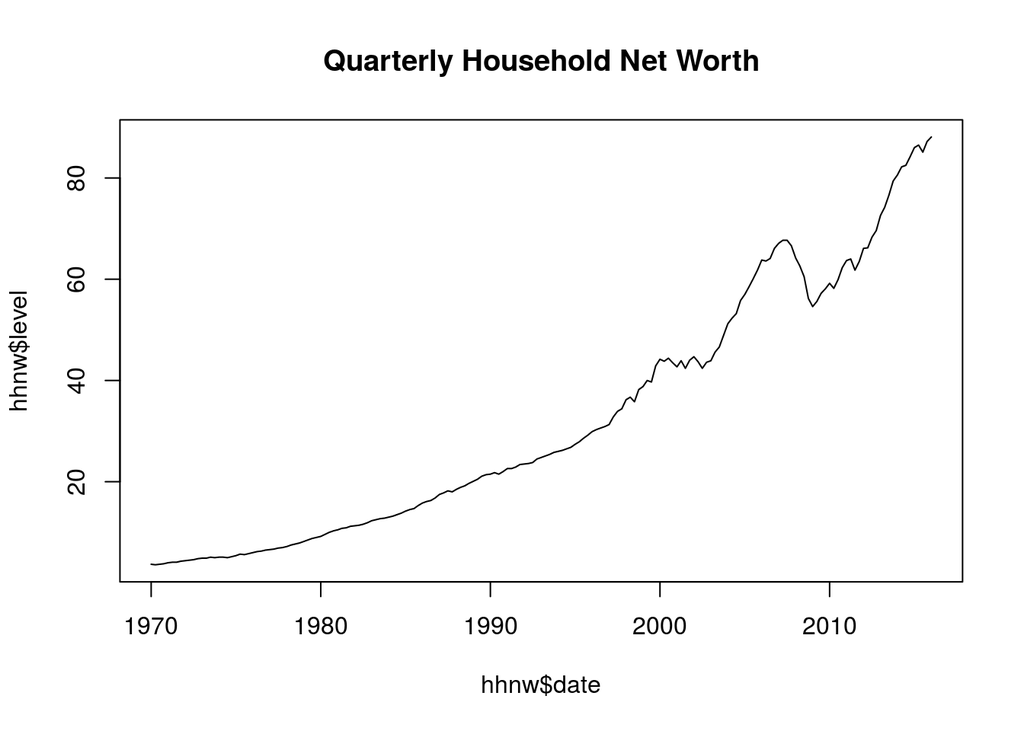

```r
# Visualize every observation in the time series with a line plot
plot(hhnw$date, hhnw$level, type = "l", main = "Quarterly Household Net Worth")
```

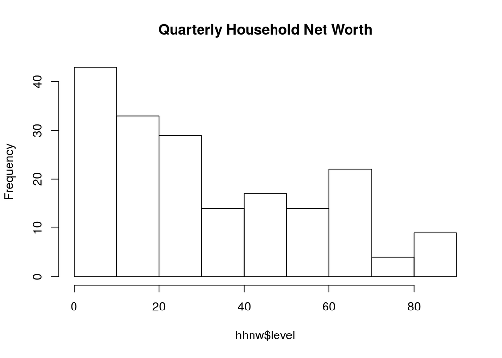

```r
# Visualize distribution with histogram
hist(hhnw$level, main = "Quarterly Household Net Worth")
```

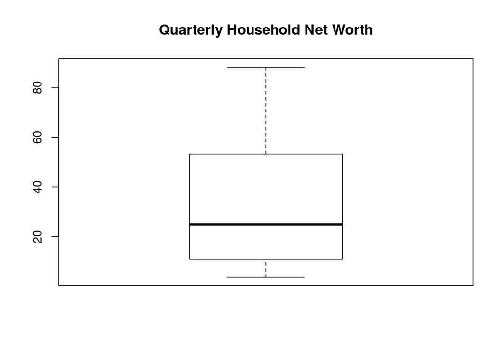

```r
# visualize distribution with boxplot
boxplot(hhnw$level, main = "Quarterly Household Net Worth")
```

Compare subsets

```r
# Create subsets of the data frame
pre_crisis  <- subset(hhnw, hhnw$date <  as.Date("2007-06-01"))
post_crisis <- subset(hhnw, hhnw$date >= as.Date("2007-06-01"))

# Descriptive statistics
summary(pre_crisis)
```

```
##       date                level
##  Min.   :1970-01-01   Min.   : 3.600
##  1st Qu.:1979-04-23   1st Qu.: 8.575
##  Median :1988-08-16   Median :19.450
##  Mean   :1988-08-15   Mean   :23.486
##  3rd Qu.:1997-12-09   3rd Qu.:35.450
##  Max.   :2007-04-01   Max.   :67.700
```

```r
summary(post_crisis)
```

```
##       date                level
##  Min.   :2007-07-01   Min.   :54.60
##  1st Qu.:2009-08-16   1st Qu.:61.15
##  Median :2011-10-01   Median :66.20
##  Mean   :2011-10-01   Mean   :69.47
##  3rd Qu.:2013-11-16   3rd Qu.:80.00
##  Max.   :2016-01-01   Max.   :88.10
```

```r
quantile(pre_crisis$level)
```

```
##     0%    25%    50%    75%   100%
##  3.600  8.575 19.450 35.450 67.700
```

```r
quantile(post_crisis$level)
```

```
##    0%   25%   50%   75%  100%
## 54.60 61.15 66.20 80.00 88.10
```

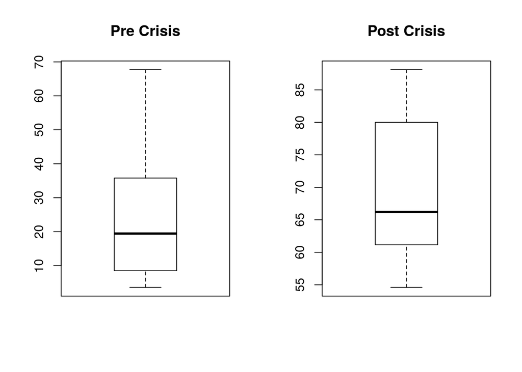

```r
# side-by-sde plots
par(mfrow=c(1,2))
boxplot(pre_crisis$level, main = "Pre Crisis")
boxplot(post_crisis$level, main = "Post Crisis")
```

- Can we do better?
- What can we improve?

### Step 5 - More Data Cleaning - this is an iterative process

Additional problems

1. we have limited information with a single time series
   1. level measure only: no flows, growth rates, etc.
   2. important dates are not explicitly marked
2. Creating a new data frame for every subset is not sustainable
3. Readable dates would be nice

Fixes

1. Compute new variables, and add more data to the data frame
   1. flow measure: $\textrm{flow}_t = \textrm{level}_{t} - \textrm{level}_{t-1}$
   2. growth rate: $\textrm{growth}_t = 100 * \textrm{flow}_{t} \textrm{level}_{t-1}$
2. categorize or label each observation – identify recession periods
3. create alternative dates

First, get more data. Download recession data from [FRED](https://fred.stlouisfed.org/release?rid=242)): [NBER based Recession Indicators for the United States from the Period following the Peak through the Trough](https://fred.stlouisfed.org/series/USRECQ)

We will need a convenient way to compute lags in a data frame. The built in lag() function does not work on generic data objects.

```r
# R functions are objects that contain instructions

prior_value <- function(x, k=1) {
    x <- c(rep(NA, k), head(x, -k))
    return(x)
}

next_value <- function(x, k=1) {
    x <- c(tail(x, -k), rep(NA, k))
    return(x)
}
```

```r
# Test with simple sequece
foo <- 1:10
prior_value(foo) # lag
next_value(foo) # lead
foo - prior_value(foo) # compute change
```

[output not shown]

Rebuild our data set with the new components

```r
# Start fresh
rm(hhnw, pre_crisis, post_crisis, foo)
#---- Get Raw Data ----#

hhnw <- read.csv("data/TNWBSHNO.csv", na.strings=".", stringsAsFactors = FALSE)


#---- Clean up raw data ----#

# set names
names(hhnw) <- c("date", "level")

# Convert the character type into a date type
hhnw$date <- as.Date(hhnw$date, format="%Y-%m-%d")

# convert millions to billions
hhnw$level <- round(hhnw$level / 1000, digits = 1)


#---- Compute new series ----#

# compute the flow (change in level)
hhnw$flow <- hhnw$level - prior_value(hhnw$level)

# compute the growth rate (one quarter trend)
hhnw$growth <- 100 * ( hhnw$flow ) / prior_value(hhnw$level)


#---- Add categorical labels etc. ----#

# Label quarters
hhnw$year <- as.integer(format(hhnw$date, "%Y"))

hhnw$q <- ceiling(as.integer(format(hhnw$date, "%m")) / 3)

hhnw$quarter <- paste(hhnw$year, hhnw$q, sep=":Q")

#----  Exclude early observations
hhnw <- subset(hhnw, hhnw$date >= as.Date("1970-01-01"))

# create a simple index for time
hhnw$t <- seq(1, nrow(hhnw))
```

Merge in recession indicator

```r
# After inpecting the raw data, read it into R
# use ?read.csv command to view explanation of these parameters
cycle <- read.csv("data/USRECQ.csv", col.names=c("date", "recession"), colClasses = c("Date", "integer"), stringsAsFactors = FALSE)

# Merge the two data sets
hhnw <- merge(hhnw, cycle, by = "date", all.x = TRUE)

# Fill in missing values with zero
hhnw$recession <- ifelse(is.na(hhnw$recession), 0, hhnw$recession)

# Look at the data (again)
str(hhnw)
```

```
## 'data.frame':    185 obs. of  9 variables:
##  $ date     : Date, format: "1970-01-01" "1970-04-01" ...
##  $ level    : num  3.7 3.6 3.7 3.8 4 4.1 4.1 4.3 4.4 4.5 ...
##  $ flow     : num  0.1 -0.1 0.1 0.1 0.2 ...
##  $ growth   : num  2.78 -2.7 2.78 2.7 5.26 ...
##  $ year     : int  1970 1970 1970 1970 1971 1971 1971 1971 1972 1972 ...
##  $ q        : num  1 2 3 4 1 2 3 4 1 2 ...
##  $ quarter  : chr  "1970:Q1" "1970:Q2" "1970:Q3" "1970:Q4" ...
##  $ t        : int  1 2 3 4 5 6 7 8 9 10 ...
##  $ recession: num  1 1 1 1 0 0 0 0 0 0 ...
```

```r
head(hhnw)
```

```
##         date level flow    growth year q quarter t recession
## 1 1970-01-01   3.7  0.1  2.777778 1970 1 1970:Q1 1         1
## 2 1970-04-01   3.6 -0.1 -2.702703 1970 2 1970:Q2 2         1
## 3 1970-07-01   3.7  0.1  2.777778 1970 3 1970:Q3 3         1
## 4 1970-10-01   3.8  0.1  2.702703 1970 4 1970:Q4 4         1
## 5 1971-01-01   4.0  0.2  5.263158 1971 1 1971:Q1 5         0
## 6 1971-04-01   4.1  0.1  2.500000 1971 2 1971:Q2 6         0
```

```r
tail(hhnw)
```

```
##           date level flow     growth year q quarter   t recession
## 180 2014-10-01  84.2  1.7  2.0606061 2014 4 2014:Q4 180         0
## 181 2015-01-01  86.0  1.8  2.1377672 2015 1 2015:Q1 181         0
## 182 2015-04-01  86.5  0.5  0.5813953 2015 2 2015:Q2 182         0
## 183 2015-07-01  85.1 -1.4 -1.6184971 2015 3 2015:Q3 183         0
## 184 2015-10-01  87.2  2.1  2.4676851 2015 4 2015:Q4 184         0
## 185 2016-01-01  88.1  0.9  1.0321101 2016 1 2016:Q1 185         0
```

```r
# maybe even print 5 random rows of data
set.seed(20160916)
hhnw[sort(sample(1:nrow(hhnw), 5)),]
```

```
##           date level flow    growth year q quarter   t recession
## 24  1975-10-01   5.8  0.2  3.571429 1975 4 1975:Q4  24         0
## 68  1986-10-01  16.8  0.5  3.067485 1986 4 1986:Q4  68         0
## 135 2003-07-01  46.6  1.0  2.192982 2003 3 2003:Q3 135         0
## 161 2010-01-01  59.2  1.1  1.893287 2010 1 2010:Q1 161         0
## 162 2010-04-01  58.2 -1.0 -1.689189 2010 2 2010:Q2 162         0
```

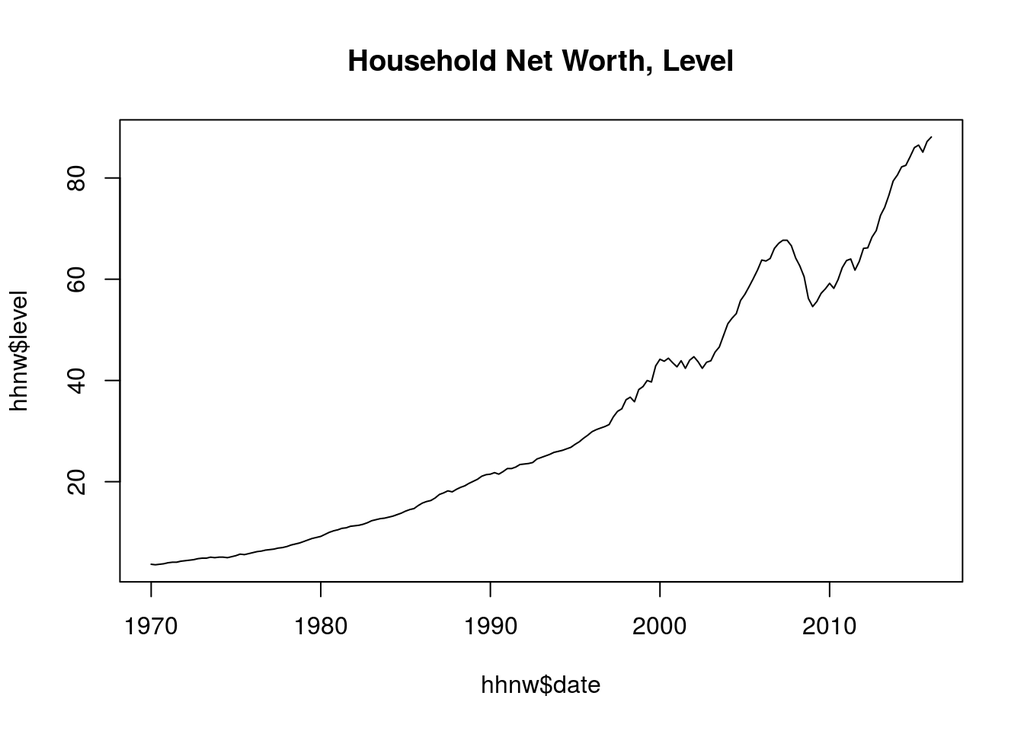

```r
plot(hhnw$date, hhnw$level, type="l", main = "Household Net Worth, Level")
```

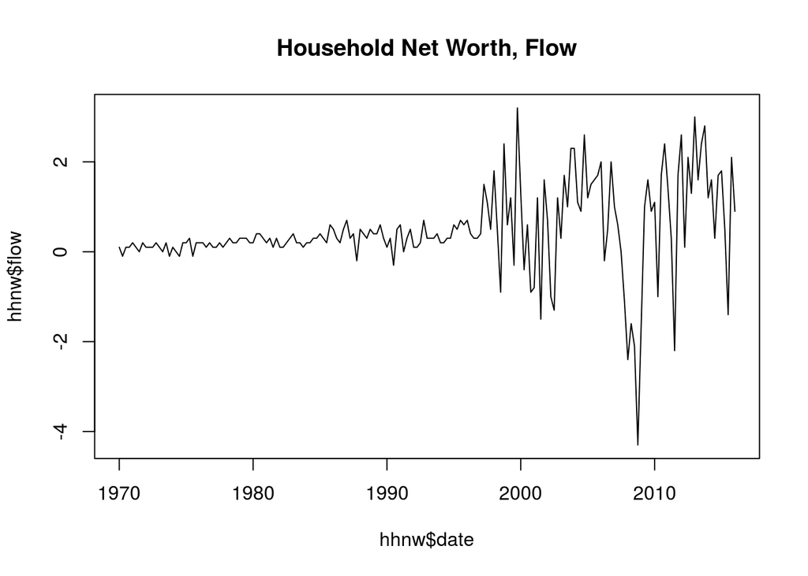

```r
plot(hhnw$date, hhnw$flow, type="l", main = "Household Net Worth, Flow")
```